# Final Results: Effects of Sex and Mixing on Male-Bias of TB

# Simulation study

In this simulation study of pathogens spreading on contact networks, we sex-assortativity (r=0 to 0.6 by 0.2) and sex-trait ratios ($\alpha$) to see how the ratio of male-female cases changes. Assorted networks were generated in two ways: with methods in Sah et al. (2019) and with a re-wiring algorithm which selectively re-wires same-sex edges until the desired level of assortativity is reached (within a small value, $\epsilon=0.05$). We investigated the following sex-traits: susceptibility (SUS), infectious period (IP), and transmissibility (TRA). We investigated different strengths of these sex-traits ($\alpha$).

Rates of susceptibility for nodes (SUS) was modeled as

| Source -> Target | Overall transmission rate, $\beta$ |
| --- | --- |
| F->F | $\frac{2 \tau } {(\alpha + 1)}$ |
| M->M | $\frac{2 \tau \alpha} {(\alpha + 1)}$ |
| M->F | $\frac{2\tau } {(\alpha + 1)}$ |
| F->M | $\frac{2 \tau \alpha} {(\alpha + 1)}$ |

Rates of transmissibility (TRA) for nodes was modeled as

| Source -> Target | Overall transmission rate, $\beta$ |
| --- | --- |
| F->F | $\frac{2 \tau } {(\alpha + 1)}$ |
| M->M | $\frac{2 \tau \alpha} {(\alpha + 1)}$ |
| M->F | $\frac{ 2 \tau \alpha} {(\alpha + 1)}$ |
| F->M | $\frac{2 \tau} {(\alpha + 1)}$ |

Infectious period (INF) for nodes modeled as

| Source | Overall transmission rate, $\beta$ |
| --- | --- |
| F | $\frac{\gamma (\alpha + 1) } {2}$ |
| M | $\frac{\gamma (\alpha + 1) } {2\alpha}$ |

Each sex-trait was modeled separately.

Sensitivity parameters tested:

1. transmission rate ($\tau=0.04, 0.075, 0.1$, $R_0=1.5, 2.5, 3.5$)
2. model type (SIR, SLIR, SIRS, SLIRS). SIRS and SLIRS models ran for 200 time units.
3. Network type: SW, SF
4. Generating algorithm: re-wiring and Sah et al. (2019)

Response variables:

1. Male-bias: calculated differently for SIR/SLIR and SIRS/SLIRS. For models without recovery: number of male recovered nodes at end of simulation divided by number of female recovered nodes at end of simulation. For models with recovery: average ratio of male cases to female cases in last 100 time units for each simulation.
2. Epidemic duration: calculated for SIR/SLIR models as the number of time units before infectious population reached 0.
3. Total number infected: calculated for SIR/SLIR models as the total number of individuals that became infected before infectious population reached 0.
4. Endemic equilibrium: calculated for SIRS/SLIRS models as the size of the infected population at the last time step
5. Prevalence of latent infection: calculated for SLIRS model as the size of the latent population at the last time step

# Structure of assorted networks

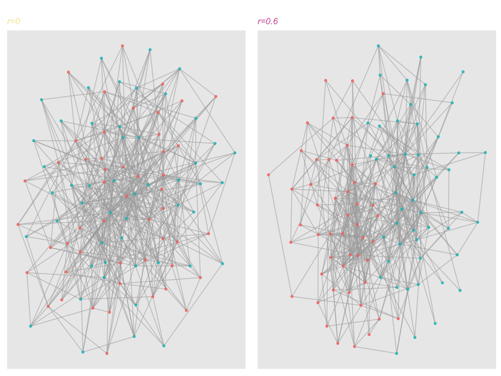

We see from the plot above that, with the exception of the Sah algorithm, important network statistics change as assortativity increases. This is not surprising given that the Sah algorithm is designed to hold other parameters constant. This is something to keep in mind as other results are interpreted.

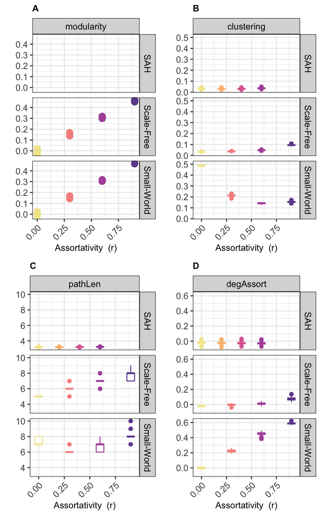

Changes in network statistics using the re-wiring algorithm to make networks of varying assortativity.

# Model parameters: $R_0$

Below we examine the relationship between the epidemic threshold ($R_0=1$) as calculated in Kiss, Miller, & Simon (2017) and simluated epidemics on networks with different values of $\tau$. Other parameters are given in figure caption. The epidemic threshold is given by:

$\frac{\tau <K^2-K>}{\tau+\gamma <K>}>1$

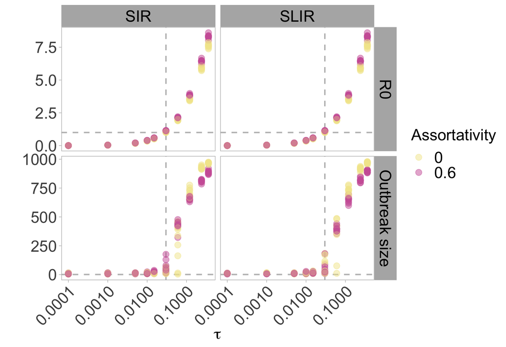

We see that the threshold matches up with simulated results (i.e., where $R_0=1$) epidemics are possible (i.e., outbreak size > $I_0$).

# Model parameters: Equilibrium of latent infections and sex-bias

While the problem investigated with these models is inspired by TB, the models themselves are very simple, and not parameterized to any specific dataset. A marked trait of TB is that, globally, 25% of the world’s population has latent infection. Here, we investigate the equilibrium latent infections and case ratio for different infection rates and strengths of sex traits. We think these data points give an idea of the parameters that we should be focusing on with these models specifically for investigating male-bias in TB.

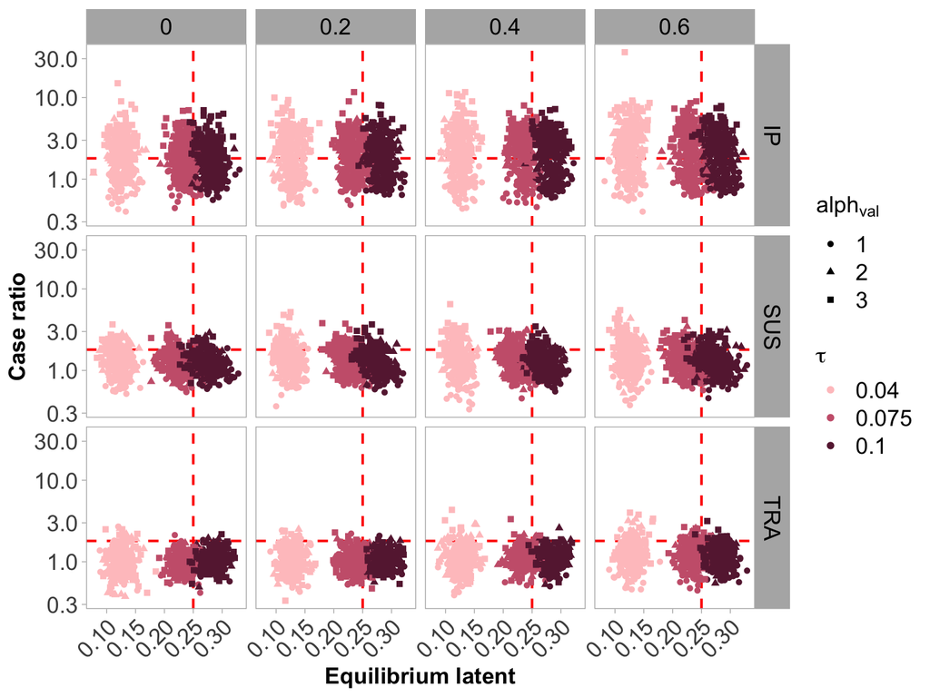

Latent equilibrium and case-ratio on Sah networks.

It looks like $\tau=0.075$ or $\tau=0.1$ results in an equilibrium latent prevalence of 25%. In the next section, we look at our results in slowest spreading situation ($\tau=0.04, R_0=1.5$) and our fastest spreading situation ($\tau=0.1, R_0=3.5$). According to the latent equilibrium plots above, the faster spreading scenario is more realistic for TB.

# Assortativity & Male Bias In Different Model Types

Next we choose a value of $\tau$ to represent a slower spreading infection to analyze male-bias across assortativity and model type in the different model types. Below shows results on Sah networks.

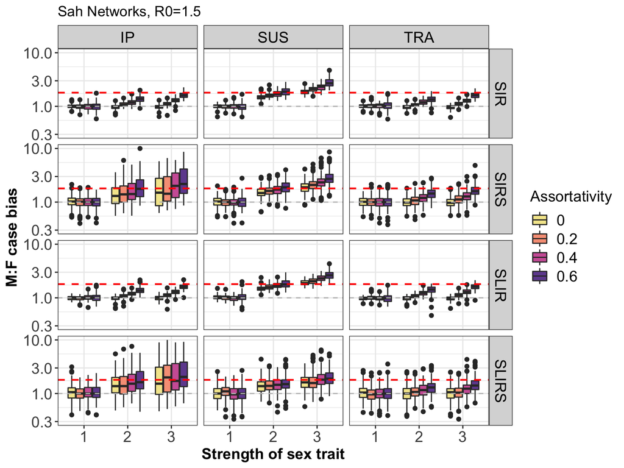

Results for the Sah networks above are representative of male-bias/assortativity results from other networks:

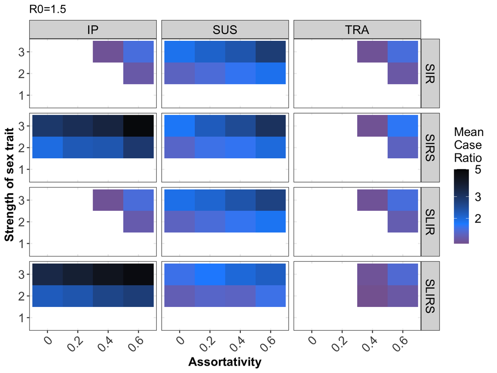

The effects of sex-traits and assortativity on male-bias in simulations on SAH-networks. Results shown for low transmissability pathogen. Only ratios above 1.25 are shown to visualize which parameter combinations in which models can lead to male-bias.

This plot clearly shows possible combinations that lead to male-bias. While assortativity is not necessary, in a few cases it can lower the strength of sex-trait required to lead to male-bias.